# La place croissante des réseaux sociaux chez les étudiants

Rachel et Léa

2023

Dans un monde qui se numérise de plus en plus, **le marché des réseaux sociaux est en forte hausse**. La croissance du nombre d’entreprises dans le secteur a permis une augmentation de la concurrence sur ce marché, les entreprises doivent alors lutter et innover afin de rester dans la course.  
Par conséquent, il nous est paru pertinant d’étudier l’utilisation des réseaux sociaux chez les étudiants en licence d’Economie à l’[université de Tours](https://www.univ-tours.fr/).

# 1 Etude de l’utilisation des réseaux sociaux

Ces dernières années nous avons observé une diversification du nombre de plateformes sociales. Les applications sont utilisées à des fins différentes et de manières diverses selon la population, mais quels sont les réseaux sociaux les plus utilisés ?

Nous avons questionné les étudiants de l’université de Tours à ce sujet.

[figure not shown]

On peut constater que le réseau social [Instagram](https://www.instagram.com/) est en tête du classement !

Etudions ces résultats de façon plus précise :

Tout d’abord, nous pouvons nous demander si l’usage d’un type de réseau social est lié au niveau d’étude.  
Pour ce faire, nous avons réaliser un test statistique d’indépendance.

```
## min. eff.théo       p-value
##     0.4759615     0.3083209
```

A l’issue de ce test on constate que la p-value est assez grande, on ne peut donc pas rejetter l’hypothèse nulle, c’est-à-dire qu’**il n’y a pas de relation de dépendance entre le type de réseaux sociaux utilisé par l’étudiant et son année d’étude**.  
Toutefois, ces résultats sont à considérer avec du recul car une des conditions de validité du test du chi-deux n’est pas vérifiée, un effectif théorique est inférieur à 5.

Ensuite, regardons le lien potentiel qu’il pourrait exister entre le réseau social le plus utilisé et le genre.  
Pour cela nous allons réaliser un second test d’indépendance.

```
## min. eff.théo       p-value
##     1.0673077     0.1752881
```

Ici, aussi la p-value reste élevée, on ne peut toujours pas rejetter l’hypothèse nulle, par conséquent **le réseau social le plus utilisé est indépendant du genre** de l’étudiant.  
Cependant, un effectif théorique est également inférieur à 5 dans ce test.

# 2 Etude du temps passé sur les écrans

## 2.1 Temps passé sur les réseaux sociaux

Les réseaux sociaux sont utilisés dans des montants horaires différents selon l’âge de la population.  
Une étude de la société [Médiamétrie](https://www.mediametrie.fr/fr) a révélé que les internautes français, de 15 à 25 ans, passaient environ 2h19 sur les réseaux sociaux chaque jours.  
Voyons si cette tendance se retrouve au sein des étudiants de Tours.

Nous allons étudier le temps passé par jour sur les réseaux sociaux selon l’année d’étude des étudiants.

Temps passé sur les réseaux sociaux

|  | Moins de 2h 0 | Moins de 2h 0.17 | Moins de 2h 0.3 | Moins de 2h 0.5 | Moins de 2h 1 | Moins de 2h 1.5 | Entre 2h et 4h 2 | Entre 2h et 4h 2.5 | Entre 2h et 4h 3 | Entre 2h et 4h 3.3 | Entre 2h et 4h 3.5 | Entre 2h et 4h 4 | Plus de 4 heures 5 | Plus de 4 heures 6 | Plus de 4 heures 7 | Plus de 4 heures 8 | Plus de 4 heures 10 |
| --- | --- | --- | --- | --- | --- | --- | --- | --- | --- | --- | --- | --- | --- | --- | --- | --- | --- |
| L1 | 1 | 1 | 1 | 3 | 23 | 6 | 32 | 2 | 26 | 0 | 1 | 17 | 6 | 8 | 1 | 2 | 1 |
| L2 | 0 | 0 | 0 | 1 | 10 | 1 | 9 | 1 | 5 | 1 | 0 | 3 | 0 | 1 | 0 | 1 | 0 |
| L3 | 1 | 0 | 0 | 2 | 9 | 6 | 9 | 2 | 6 | 0 | 0 | 3 | 2 | 0 | 3 | 1 | 0 |

En moyenne, les étudiants de l’université de Tours passent **2.7 heures** par jour sur les réseaux sociaux.

Plus exactement, on peut observer les moyennes du temps passé sur les réseaux sociaux en fonction de l’année d’étude :

- En moyenne, les étudiants en **première année** de licence d’économie passent *2.8* heures par jour sur les réseaux sociaux
- En moyenne, les étudiants en **seconde année** passent *2.3* heures par jour sur les réseaux sociaux
- En moyenne, les étudiants en **dernière année** de liecence passent *2.5* heures par jour sur les réseaux sociaux

Pour une meilleure visualisation du temps passé sur les réseaux sociaux chaque jour, nous représentons la distribution des répondants en fonction de leur genre et de leur niveau d’étude.

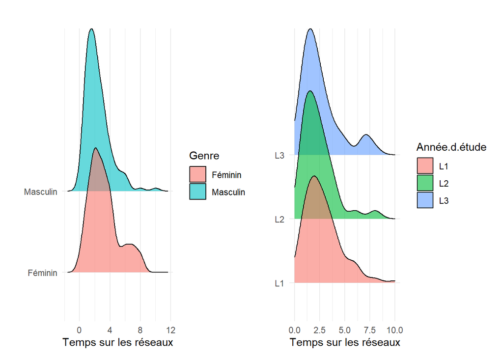

## 2.2 Temps passé sur le téléphone

Pour naviguer sur les réseaux sociaux, et plus largement sur internet, c’est le téléphone qui domine les autres appareils.  
Il est alors intéressant de se préoccuper du temps passé par les individus sur leur téléphone.

Nous allons regarder le temps passé par les étudiants sur leur téléphone selon les années d’études.

Temps passé sur le téléphone

|  | Moins de 4 heures 1 | Moins de 4 heures 1.5 | Moins de 4 heures 2 | Moins de 4 heures 2.5 | Moins de 4 heures 3 | Moins de 4 heures 3.5 | Entre 4 heures et 8h 4 | Entre 4 heures et 8h 4.5 | Entre 4 heures et 8h 5 | Entre 4 heures et 8h 6 | Entre 4 heures et 8h 6.5 | Entre 4 heures et 8h 7 | Entre 4 heures et 8h 8 | Plus de 8 heures 8.5 | Plus de 8 heures 9 | Plus de 8 heures 10 | Plus de 8 heures 12 | Plus de 8 heures 15 | Plus de 8 heures 18 | Plus de 8 heures 24 |
| --- | --- | --- | --- | --- | --- | --- | --- | --- | --- | --- | --- | --- | --- | --- | --- | --- | --- | --- | --- | --- |
| L1 | 2 | 2 | 8 | 2 | 15 | 1 | 25 | 0 | 30 | 17 | 1 | 8 | 12 | 1 | 1 | 3 | 1 | 1 | 0 | 1 |
| L2 | 0 | 0 | 1 | 1 | 8 | 0 | 11 | 0 | 3 | 3 | 0 | 3 | 3 | 0 | 0 | 0 | 0 | 0 | 0 | 0 |
| L3 | 1 | 0 | 3 | 3 | 7 | 1 | 6 | 1 | 9 | 4 | 0 | 2 | 1 | 0 | 2 | 1 | 2 | 0 | 1 | 0 |

En moyenne, les étudiants de l’université de Tours passent **5.1 heures** par jour sur leur téléphone.

Il apparait que le temps passé sur le téléphone n’est pas identique au temps passé sur les réseaux sociaux.  
Nous le savons, l’usage du smartphone s’est fortement accru. Mais cet appareil n’est pas entièrement consacré à l’utilisation des réseaux sociaux, n’en oubliant pas sa fonction première qui est de pouvoir passer des appels.  
En outre, les utilisateurs se servent de leur téléphone pour écouter de la musique, jouer à des jeux vidéos, lire les actualités, etc.

# 3 Etude des corrélations possibles avec les réseaux sociaux

## 3.1 Corrélation avec le temps d’écran

Intéressons nous plus rigoureusement à la possible corrélation entre le temps passé sur les réseaux sociaux et le temps passé sur le téléphone :

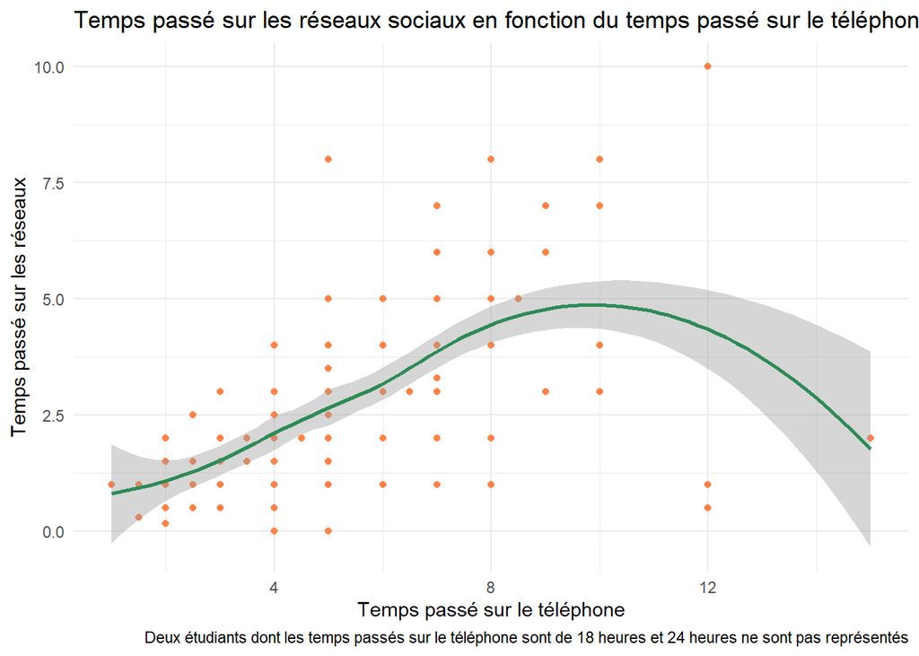

Ce graphique nous permet de tirer plusieurs conclusions.

Tout d’abord nous remarquons qu’une certaine tendance se dégage de cette étude. Il est apparent qu’il existe une relation positive entre le temps passé par les étudiants sur les réseaux sociaux et le temps passé sur leur téléphone.

**Plus le temps passé sur les réseaux sociaux augmente, plus le temps d’écran passé sur téléphone augmente**, ce qui suit la logique précédente où le smartphone est la principale plateforme pour l’usage des réseaux sociaux.

Cependant on remarque que quelques étudiants font exception, ils passent de longue durée sur leur téléphone mais peu sur les réseaux sociaux.

## 3.2 Corrélation avec des individus spécifiques

Il y a plus de 4,76 milliards d’utilisateurs quotidiens de réseaux sociaux dans le monde, soit environ 60% de la population mondiale.  
En France ce chiffre s’élève à **38 millions d’utilisatuers**.

Or, nous savons que l’utilisation des réseaux sociaux se fait pour des raisons différentes, de façons différentes et de durées différentes selon des caractéristiques spécifiques de la population, comme par exemple les régions du monde et l’âge.

Intéressons nous à la différence qu’il peut exister entre le temps que passe sur les réseaux sociaux les étudiants et étudiantes en Economie.

```
##                mean in group Féminin               mean in group Masculin
##                          3.186486486                          2.354253731
## Borne inf. de l'IC à 95% de la diff. Borne sup. de l'IC à 95% de la diff.
##                          0.308049539                          1.356415971
##                              p-value
##                          0.002091762
```

En réalisant un test statique d’égalité de moyennes, on peut observer que la p-value est très faible, on peut donc rejeter l’hypothèse de nullité, c’est-à-dire que **le temps passé sur les réseaux sociaux est différent selon le genre**.

On peut plus nettement observer cette distinction en regardant spécifiquement la situation de chaque groupe d’individus.

Bilan du temps sur les réseaux sociaux pour les Femmes

|  | x |
| --- | --- |
| Moyenne | 3.2 |
| Écart type | 2.0 |
| Minimum | 0.0 |
| Q1 | 2.0 |
| Médiane | 3.0 |
| Q3 | 4.0 |
| Maximum | 8.0 |

Bilan du temps sur les réseaux sociaux pour les Hommes

|  | x |
| --- | --- |
| Moyenne | 2.4 |
| Écart type | 1.6 |
| Minimum | 0.0 |
| Q1 | 1.0 |
| Médiane | 2.0 |
| Q3 | 3.0 |
| Maximum | 10.0 |

Grâce à ces tableaux résumés, nous pouvons remarquer que **la moyenne du temps passé sur les réseaux sociaux est plus élevée chez les femmes que chez les hommes**.

## 3.3 Corrélation avec le temps de travail personnel

Une journée est composée d’un nombre finie d’heures : **Comment les étudiants organisent-ils leur temps entre étude et réseaux sociaux ?**

Après avoir étudié le temps passé sur les réseaux sociaux sous toutes ses facettes, nous pouvons également regarder l’impact que celui-ci peut avoir sur le temps de travail personnel des étudiants.

Premièrement étudions le temps consacré aux *travail personnel* par les étudiants :

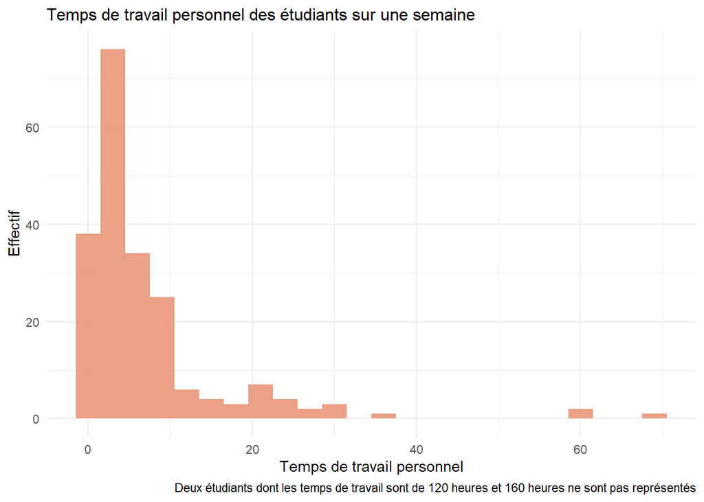

Qu’en est-il de son lien avec le temps passé sur les réseaux sociaux ?

[figure not shown]

Au vu de ce graphique, il n’est pas facile de constater une potentielle corrélation entre le temps passé sur les réseaux sociaux et le temps consacré au travail personnel par les étudiants.

En moyenne par semaine, les étudiants accordent **8.4 heures** pour leur travail personnel.  
Cette moyenne est assez basse, seulement un peu plus d’1 heure par jour.

Néanmoins, nous pouvons nous questionner sur la semaine qui a été prise en référence.  
Ces valeurs ne sont peut-être pas représentative de la réalité, puisque le sondage a été réalisé au début de l’année scolaire. Il est possible que les étudiants ne s’étaient pas encore mis à travailler assidument.